# Milestone Report

Jinge Zhang

4/17/2020

## Milestone Report

The report will include exploratory data analysis on the input datasets, aka news + blogs + twitter. For simplicity, I’m using English version to demostrate. However, the input datasets with other language should follow the same route with minimal modifications.

## Basic Data Summary

```
##   data_source line_count word_count
## 1        news    1010242   34372530
## 2       blogs     899288   37334131
## 3     twitter    2360148   30373583
```

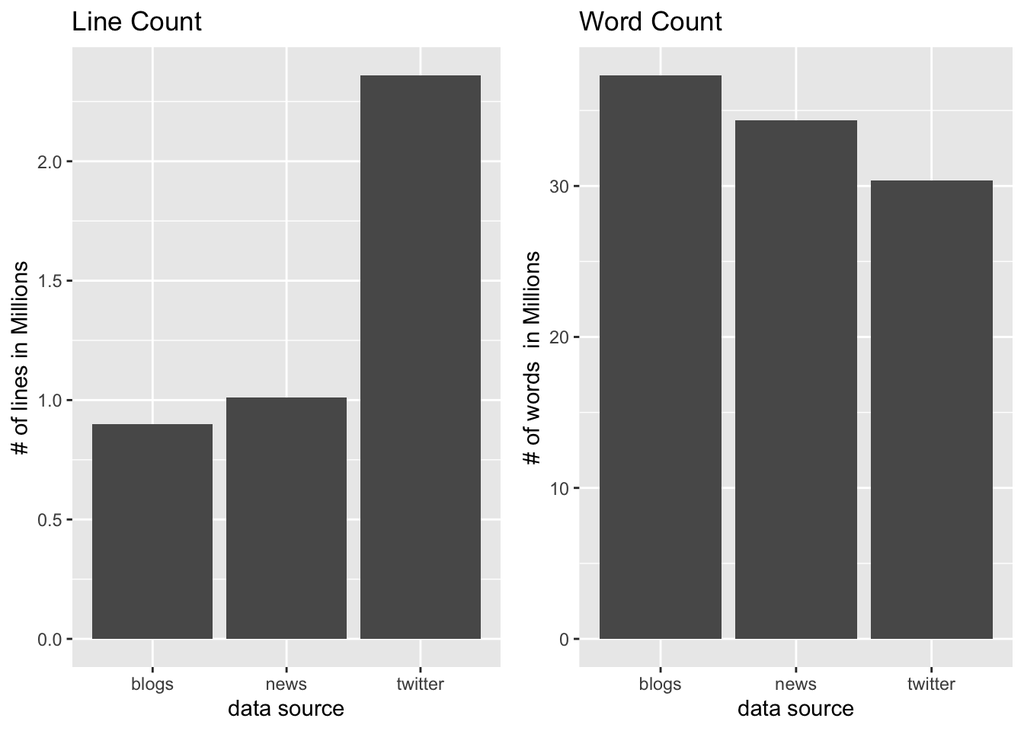

## Create Corpus with tokenization

By utilizing the Text Mining Package **tm**, a corpus will be created, with the following tokenization pipelines:

0. To Lowercase
1. Strip White Space(s).
2. Stem Words, based on [Porter’s stemming algorithm.](http://snowball.tartarus.org/algorithms/porter/stemmer.html)
3. Remove Language Specific Stopwords.
4. Remove Numbers.
5. Removing content that starts with “**http**”, case insensitive. This step is to ensure removing URL related content mainly from Twitter feeds.
6. Remove Puntuations.
7. Remove 1-2 letter words.

Due to different contexts among different sources, I create one corpus per data source. That is, one corpus for News, one corpus for Blogs and one corpus for Twitter Feeds.

Since the raw data source has millions of lines per data source, I’ll sample 5% of the data per source. Besides, the milestone report doesn’t specify whether we need to use all of data to perform data analysis. If using all of the data source, it would fairly painful to see similar behaviors compared to a 5% sample in terms of illustrating the distribution of words, n-grams, etc.

```
## <<DocumentTermMatrix (documents: 50512, terms: 62510)>>
## Non-/sparse entries: 898922/3156606198
## Sparsity           : 100%
## Maximal term length: 46
## Weighting          : term frequency (tf)
## Sample             :
##        Terms
## Docs    also get like new one said state time will year
##   17760    0   0    0   1   0    0     1    0    0    1
##   20656    0   0    0   0   0    7     1    0    1    0
##   24799    0   0    0   0   0    0     0    0    1    5
##   32609    1   0    0   2   0    0     0    0    0    1
##   33177    2   0    0   0   1    0     0    0    3    5
##   34886    0   0    0   0   1    0     0    2    0    0
##   35564    0   0    3   2   0    0     0    1    1    0
##   42033    0   2    2   2   0    0     0    1    1    1
##   47473    1   0    2   0   2    1     0    0    0    0
##   963      1   0    0   0   2    0     0    0    0    2
```

## Exploratory Analysis

### Word Frequency

Below are the plots of words with most frequencies.

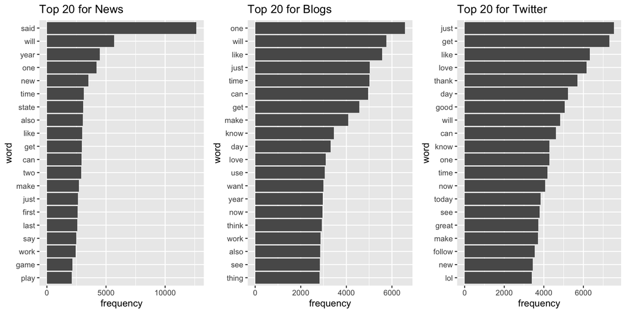

### How Many Unique Words to Achieve 50% & 90% Coverage.

Below is the table and barplot for Unique Word Coverage, by different data sources.

```
##   data_source fifty_percent_coverage ninty_percent_coverage
## 1        news                    761                  11226
## 2       blogs                    618                  10481
## 3     twitter                    400                   9137
##   total_num_unique_words
## 1                  62510
## 2                  62465
## 3                  60986
```

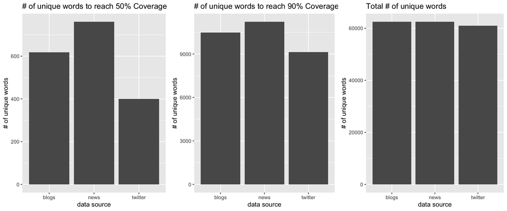

### N-gram

By utilizing the NLP pakcage, I create Document Term Matrix for bi-gram and tri-gram.

#### Bi-gram

Below are the Top 20 Bi-gram frequencies.

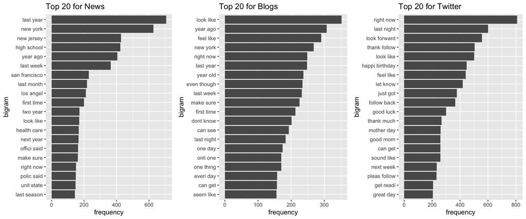

## Tri-gram

Below are the Top 20 Tri-gram frequencies.

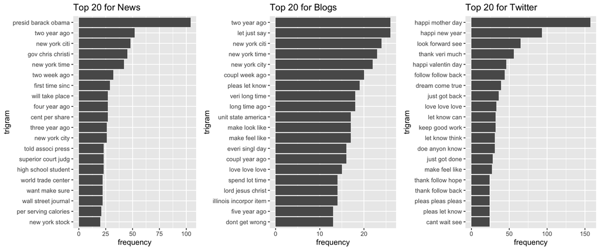

### Bi-Gram Co-occurances

The following bi-grams coexist in top 20 Bi-gram frequencies in various data sources:

```
## [1] "right now" "look like"
```

### Tri-Gram Co-occurances

The following tri-grams coexist from News and Blogs, in top 20 Tri-gram frequencies.

```
## [1] "two year ago"  "new york citi" "new york time" "new york city"
```

The following tri-grams coexist from News and Twitter, in top 20 Tri-gram frequencies.

```
## character(0)
```

The following tri-grams coexist from Blogs and Twitter, in top 20 Tri-gram frequencies.

```
## [1] "love love love" "make feel like" "pleas let know"
```

### Interesting Insights from n-grams.

From the top 20 N-grams we can see the different tones from different data sources.e.g. Twitter top Tri-grams are phrases like Happy Mother’s Day, Happy New Year, etc. whereas that from News are things like President Barack Obama, New York City, will take place, etc.

This sentimental variations somewhat explain why we need to build corpus per data source, because of the different context it would take place.

## Next Steps

1. Will revise the tokenization strategy back and forth when finding anything weired.
2. Will think about how to incorporate the full size dataset into the corpus.
3. Will design the language model as the Capstone proceeds.